# Midterm_Aritra

Aritra

2023-10-24

```r
#Clearing the environment
rm(list = ls())
```

# Question 1: Basic Data Analysis in R —check

*In 1986, the Challenger space shuttle exploded during “throttle up” due to catastrophic failure of o-rings(seals) around the rocket booster. The data (real) on all space shuttle launches prior to the Challenger disaster are in the file challenger.csv.*

```r
#Loading the libraries
library(ggplot2)
library(psych)
#Loading the dataset onto R
df_challenger <- read.csv("/Users/aritraray/Desktop/challenger.csv")
```

## a. Print the measures of center, spread and shape for the variables in the data

```r
#df_challenger
```

```r
#Describing the dataframe
describe(df_challenger)
```

```
##              vars  n  mean   sd median trimmed  mad  min  max range  skew
## launch          1 23 12.00 6.78   12.0   12.00 8.90  1.0 23.0    22  0.00
## temp            2 23 69.02 6.97   69.8   69.33 5.34 53.6 80.6    27 -0.40
## incident*       3 23  1.30 0.47    1.0    1.26 0.00  1.0  2.0     1  0.80
## o_ring_probs    4 23  0.43 0.79    0.0    0.26 0.00  0.0  3.0     3  1.81
##              kurtosis   se
## launch          -1.36 1.41
## temp            -0.44 1.45
## incident*       -1.42 0.10
## o_ring_probs     2.69 0.16
```

## b. What are the levels of measurement of these 4 variables?

- Launch: Ordinal as the values have a meaningful order
- temp: Ratio has it has a meaningful 0 point
- incident: Nominal (categorical)
- o_ring_probs: Ratio as this also has a meaning 0 point. It represents the count of 0 partial failures.

## c. Provide an appropriate graph for the variable o_ring_probs

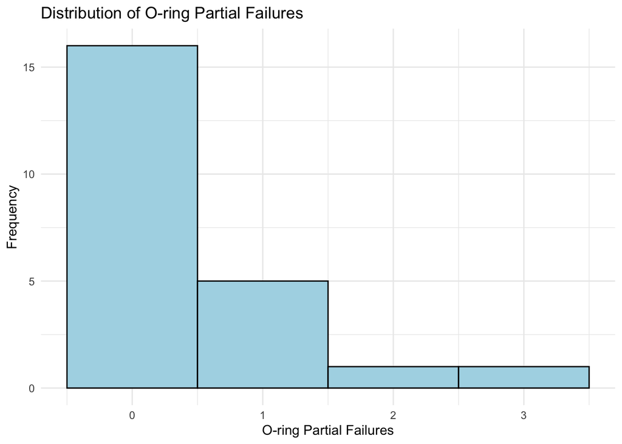

```r
# Create a histogram with colored bars
ggplot(data = df_challenger, aes(x = o_ring_probs)) +
  geom_histogram(
    binwidth = 1,
    fill     = "lightblue",
    color    = "black") +
  labs(
    x     = "O-ring Partial Failures",
    y     = "Frequency",
    title = "Distribution of O-ring Partial Failures"
  ) +
  theme_minimal()
```

## d. The temperature on the day of the Challenger launch was 36 degrees Fahrenheit. Provideside-by-side boxplots for temperature by incident (temp~incident in formula). Why might this have been a concern?

Low temperatures were a concern in the Challenger launch because they impaired the performance of O-rings and were a contributing factor to the incident. This relationship can be illustrated using boxplots.

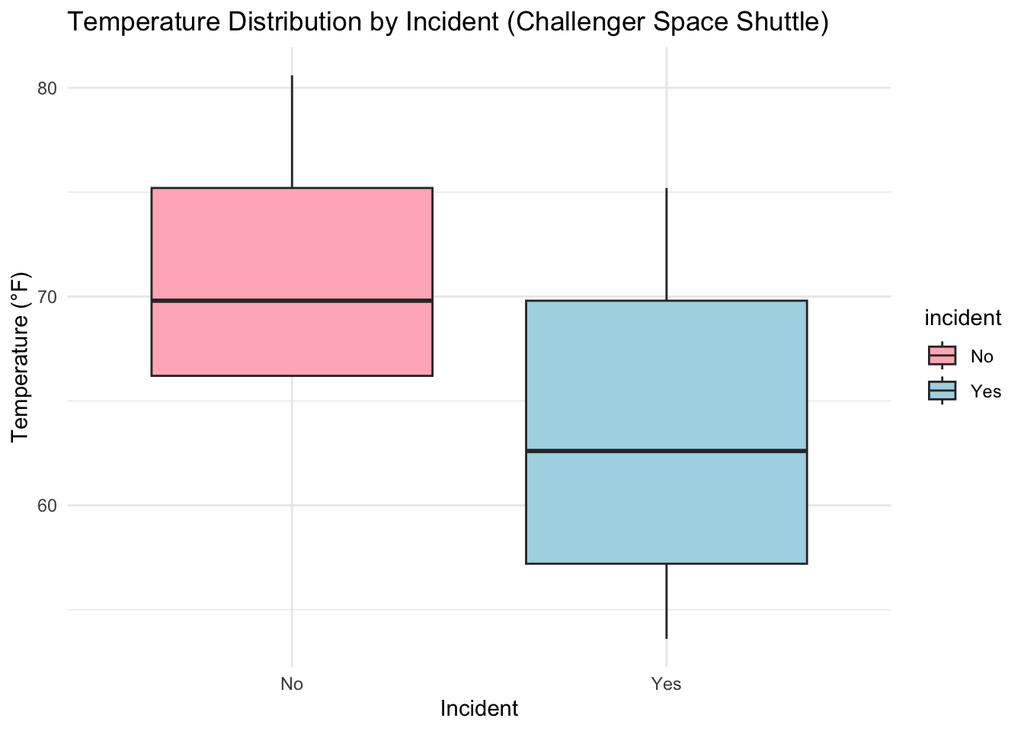

```r
#Plotting a boxplot
ggplot(data = df_challenger, aes(x = incident, y = temp, fill = incident)) +
  geom_boxplot() +
  labs(
    x     = "Incident",
    y     = "Temperature (°F)",
    title = "Temperature Distribution by Incident (Challenger Space Shuttle)"
  ) +
  scale_fill_manual(values = c("No" = "lightpink", "Yes" = "lightblue")) +
  theme_minimal()
```

## e. In the already temperature-sorted dataset (order(mydata$temp)), find on which obser-vation the first successful launch occurred (one with no incident). Answer using a command(instead of eyeballing the data).

```r
#Finding the minimum index
first_successful_launch <- min(which(df_challenger$incident == "No"))
first_successful_launch
```

```
## [1] 5
```

## f. How many incidents occurred above 65 degrees F? Answer using a command (instead of eyeballing the data).

```r
#Adding the values
incidents_above_65 <- sum(df_challenger$temp > 65)
incidents_above_65
```

```
## [1] 19
```

# Question 2: Probability and Bayes Rule

*The sensitivity and specificity of the polygraph has been a subject of study and debate for years. A 2001 study of the use of polygraph for screening purposes suggested that the probability of detecting an actual liar was .59 (sensitivity) and that the probability of detecting an actual “truth teller” was .90 (specificity). We estimate that about 20% of individuals selected for the screening polygraph will lie.*

**Solution:**

```r
# Define the given probabilities
# Probability of detecting an actual liar or True Positive Rate or P(Polygraph|Liar)
sensitivity <- 0.59
# Probability of detecting an actual truth teller or True Negative Rate
specificity <- 0.90
# Probability that an individual is a liar or P(Liar)
prior_probability_liar <- 0.20
```

## a. What is the probability that an individual is actually a liar given that the polygraphdetected him/her as such? Solve using the Bayesian formula. Be clear with your notation. Ifyou are not sure, you can try to solve as with the tree or table method for partial credit.

$$P(\text{Liar|Polygraph}) = \frac{P(\text{Polygraph|Liar}) \cdot
P(\text{Liar})}{P(\text{Polygraph})}$$

```r
# Using Bayes' theorem
# P(Liar|Polygraph) = [P(Polygraph|Liar) * P(Liar)] / P(Polygraph)
# P(Polygraph) = P(Polygraph|Liar) * P(Liar) + P(Polygraph|Truth Teller) * P(Truth Teller)

probability_liar_given_polygraph <- (sensitivity * prior_probability_liar) / (sensitivity * prior_probability_liar + (1 - specificity) * (1 - prior_probability_liar))

probability_liar_given_polygraph <- round(probability_liar_given_polygraph, 4)

cat("Probability that an individual is actually a liar given that the polygraph detected them as such:", probability_liar_given_polygraph, "\n")
```

```
## Probability that an individual is actually a liar given that the polygraph detected them as such: 0.596
```

## b. What is the probability that a randomly selected individual is either a liar or was identified as a liar by the polygraph? Be sure to write the probability statement.

$$P(\text{Liar or Identified by Polygraph}) = P(\text{Liar}) + (1 -
P(\text{Liar})) \cdot (1 - \text{Specificity})$$

```r
# b. Probability that a randomly selected individual is either a liar or was identified as a liar by the polygraph

# Using the law of total probability
probability_liar_or_identified_by_polygraph <- prior_probability_liar + (1 - prior_probability_liar) * (1 - specificity)

cat("Probability that a randomly selected individual is either a liar or was identified as a liar by the polygraph:", probability_liar_or_identified_by_polygraph, "\n")
```

```
## Probability that a randomly selected individual is either a liar or was identified as a liar by the polygraph: 0.28
```

# Question 3: Poisson and Binomial

*Your organization owns an expensive Magnetic Resonance Imaging machine (MRI). This machine has a manufacturer’s expected lifetime of 10 years i.e. the machine fails once in 10 years, or the probability of the machine failing in any given year is 1/10*

## a. What is the probability that the machine will fail after 8 years? - Poisson

```r
# Parameters
lambda <- 1/10  # Average rate of failure per year
t <- 8  # Number of years

# Probability of no failures in 8 years
probability_no_failures <- dpois(0, lambda * t)

# Expected value (mean) of the Poisson distribution
mean_poisson <- lambda * t

# Standard deviation of the Poisson distribution
sd_poisson <- sqrt(lambda * t)

cat("Probability that the machine will fail after 8 years (no failures):", round(probability_no_failures, 4), "\n")
```

```
## Probability that the machine will fail after 8 years (no failures): 0.4493
```

```r
cat("Expected value (mean) of the Poisson distribution:", mean_poisson, "\n")
```

```
## Expected value (mean) of the Poisson distribution: 0.8
```

```r
cat("Standard deviation of the Poisson distribution:", round(sd_poisson, 4))
```

```
## Standard deviation of the Poisson distribution: 0.8944
```

### Visualization

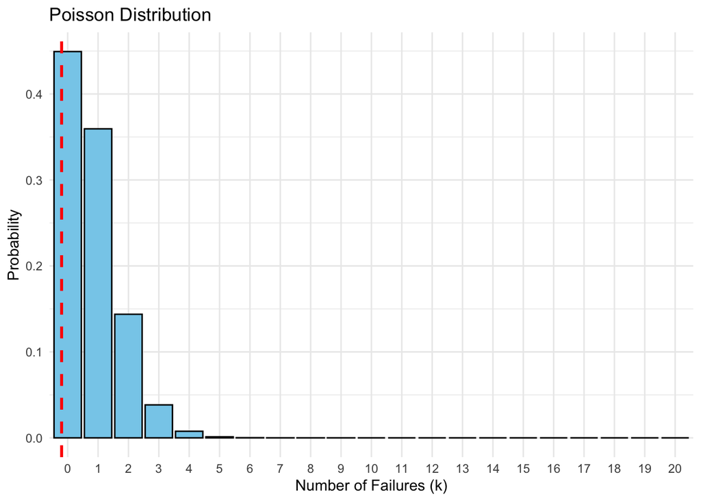

```r
# Generate data for the Poisson distribution
x <- 0:20  # Values of k (number of failures)
pmf <- dpois(x, lambda * t)  # Probability mass function

# Create a data frame for plotting
df <- data.frame(x, pmf)

#Plotting and highlighting the mean to understand dispersion
ggplot(df, aes(x = factor(x), y = pmf)) +
  geom_bar(stat = "identity", fill = "skyblue", color = "black") +
  geom_vline(xintercept = mean_poisson,
             color      = "red",
             linetype   = "dashed",
             size       = 1) +
  labs(
    title = "Poisson Distribution",
    x     = "Number of Failures (k)",
    y     = "Probability"
  ) +
  theme_minimal()
```

## b. What is the probability that the machine will fail after 8 years? - Binomial

```r
# Parameters
n <- 8  # Number of years
p <- 1/10  # Probability of failure in one year
k <- 0  # Number of failures (0 successes)

# Calculate the probability of 0 failures in 8 years using the binomial distribution
probability_binomial <- dbinom(k, size = n, prob = p)

# Calculate the expected value (mean) of the binomial distribution
mean_binomial <- n * p

# Calculate the standard deviation of the binomial distribution
sd_binomial <- sqrt(n * p * (1 - p))

cat("Probability of the machine failing after 8 years (0 failures) using a binomial distribution:", round(probability_binomial, 4), "\n")
```

```
## Probability of the machine failing after 8 years (0 failures) using a binomial distribution: 0.4305
```

```r
cat("Expected value (mean) of the binomial distribution:", mean_binomial, "\n")
```

```
## Expected value (mean) of the binomial distribution: 0.8
```

```r
cat("Standard deviation of the binomial distribution:", round(sd_binomial, 4), "\n")
```

```
## Standard deviation of the binomial distribution: 0.8485
```

# Question 4: Multiple choice quiz

*In a multiple choice quiz there are 5 questions and 4 choices for each question (a, b, c, d). Robin has not studied for the quiz at all, and decides to randomly guess the answers.*

## a. What is the probability that the first question Robin gets right is the 3rd question?

```r
# Probability of getting a question right
p_right = 1/4

# Probability of getting a question wrong
p_wrong = 3/4

# Probability that the first question Robin gets right is the 3rd question
probability_a = (p_wrong^2) * p_right

cat("a. Probability that the first question Robin gets right is the 3rd question:", round(probability_a, 4), "\n")
```

```
## a. Probability that the first question Robin gets right is the 3rd question: 0.1406
```

## b. What is the probability that Robin gets exactly 3 or exactly 4 questions right?

- Likely distribution: Binomial Distribution as it follows the four characteristics. Here;
  - n is number of trials: 5
  - p or probability of success is 1/4
  - k can be the number f successes
- Probability Statement: P(X = 3) + P(X = 4)

```r
# Number of trials (questions)
n = 5

# Probability of success (getting a question right)
p = 1/4

# Probability of getting exactly 3 questions right
probability_3 = dbinom(3, size = n, prob = p)

# Probability of getting exactly 4 questions right
probability_4 = dbinom(4, size = n, prob = p)

# Sum the probabilities to get the answer
probability_b = probability_3 + probability_4

cat("b. Probability that Robin gets exactly 3 or exactly 4 questions right:", round(probability_b, 4), "\n")
```

```
## b. Probability that Robin gets exactly 3 or exactly 4 questions right: 0.1025
```

## c. What is the probability that Robin gets the majority of the questions right?

- Probability Statement: P(X >= 3) = P(X = 3) + P(X = 4) + P(X = 5)

1st way:

```r
# Probability that Robin gets the majority of the questions right
probability_c = sum(dbinom(3:5, size = n, prob = p))

cat("c. Probability that Robin gets the majority of the questions right:", round(probability_c, 4), "\n")
```

```
## c. Probability that Robin gets the majority of the questions right: 0.1035
```

2nd way:

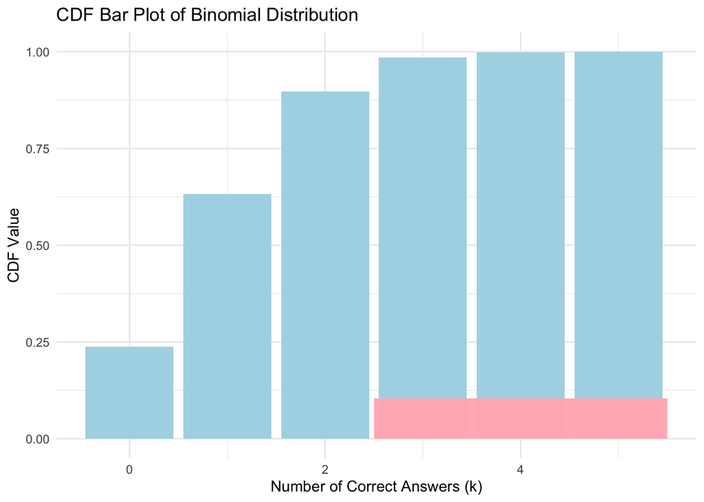

```r
# Number of trials (questions)
n <- 5

# Probability of success (getting a question right)
p <- 1/4

# Calculate the probability of getting the majority right (questions 3, 4, and 5)
probability_majority <- sum(dbinom(3:5, size = n, prob = p))

# Create a data frame for the CDF plot
k_values <- 0:n
cdf_values <- pbinom(k_values, size = n, prob = p, lower.tail = TRUE)
df <- data.frame(k = k_values, CDF = cdf_values)

# Create the CDF bar plot and fill the part for questions 3, 4, and 5
cdf_barplot <- ggplot(df, aes(x = k, y = CDF)) +
  geom_bar(stat = "identity", fill = "lightblue") +
  labs(
    title = "CDF Bar Plot of Binomial Distribution",
    x = "Number of Correct Answers (k)",
    y = "CDF Value"
  ) +
  geom_rect(aes(xmin = 3 - 0.5, xmax = 5 + 0.5, ymin = 0, ymax = probability_majority),
            fill = "lightpink", alpha = 0.5) +
  theme_minimal()

# Print the CDF bar plot
print(cdf_barplot)
```

```r
# Print the probability of getting the majority right
cat("Probability of getting the majority right:", round(probability_majority, 4))
```

```
## Probability of getting the majority right: 0.1035
```

# Question 5: Normal Distribution

## a. Speeding on the Interstate 5 Freeway (I-5) in California.

### a1.

```r
# Define the parameters
mean_speed <- 72.6  # Mean speed in miles/hour
std_deviation <- 4.78  # Standard deviation in miles/hour
target_speed <- 80  # Speed threshold in miles/hour

# Calculate the z-score for the target speed
z_score <- (target_speed - mean_speed) / std_deviation

# Use the pnorm function to calculate the probability that X is less than the target speed
probability_slower_than_80 <- pnorm(z_score)

# Convert the probability to a percentage
percentage_slower_than_80 <- round(probability_slower_than_80, 4) * 100

cat("Percentage of passenger vehicles traveling slower than 80 miles/hour:", percentage_slower_than_80, "%\n")
```

```
## Percentage of passenger vehicles traveling slower than 80 miles/hour: 93.92 %
```

### a2.

```r
# Define the parameters
mean_speed <- 72.6  # Mean speed in miles/hour
std_deviation <- 4.78  # Standard deviation in miles/hour
lower_speed <- 68  # Lower speed threshold in miles/hour
upper_speed <- 78  # Upper speed threshold in miles/hour

# Calculate the z-scores for the lower and upper speed thresholds
z_lower <- (lower_speed - mean_speed) / std_deviation
z_upper <- (upper_speed - mean_speed) / std_deviation

# Use the pnorm function to calculate the probability between the z-scores
probability_between_68_and_78 <- pnorm(z_upper) - pnorm(z_lower)

# Convert the probability to a percentage
percentage_between_68_and_78 <- round(probability_between_68_and_78, 4) * 100

cat("Percentage of passenger vehicles traveling between 68 and 78 miles/hour:", percentage_between_68_and_78, "%\n")
```

```
## Percentage of passenger vehicles traveling between 68 and 78 miles/hour: 70.28 %
```

The validity of this result is dependent on the context and traffic circumstances on the I-5 Freeway. If the speed distribution is roughly typical, as described, and there are no unique factors influencing speed distribution (e.g., construction zones or accidents), it’s realistic to assume a high number of vehicles to be going within this speed range. However, the exact percentage may vary depending on the time of day, day of the week, and other traffic-related factors.

### a3.

```r
# Define the parameters
mean_speed <- 72.6  # Mean speed in miles/hour
std_deviation <- 4.78  # Standard deviation in miles/hour
speed_limit <- 70  # Speed limit in miles/hour

# Calculate the z-score for the speed limit
z_speed_limit <- (speed_limit - mean_speed) / std_deviation

# Use the pnorm function to calculate the probability that X is greater than the speed limit
probability_above_speed_limit <- 1 - pnorm(z_speed_limit)

# Convert the probability to a percentage
percentage_above_speed_limit <- round(probability_above_speed_limit, 4) * 100

cat("Percentage of passenger vehicles traveling above the speed limit (70 miles/hour):", percentage_above_speed_limit, "%\n")
```

```
## Percentage of passenger vehicles traveling above the speed limit (70 miles/hour): 70.68 %
```

## b. Distributions for triathlon times

### b1.

```r
# Parameters for the men's group
mean_men <- 4313  # Mean time in seconds
std_deviation_men <- 583  # Standard deviation in seconds

# Percentile (5%)
percentile <- 0.05

# Find the z-score for the 5th percentile
z_score <- qnorm(percentile)

# Calculate the cutoff time for the fastest 5% of athletes
cutoff_time_men <- mean_men + z_score * std_deviation_men

cat("Cutoff time for the fastest 5% of athletes in the men's group:", cutoff_time_men, "seconds\n")
```

```
## Cutoff time for the fastest 5% of athletes in the men's group: 3354.05 seconds
```

### b2.

```r
# Parameters for the women's group
mean_women <- 5261  # Mean time in seconds
std_deviation_women <- 807  # Standard deviation in seconds

# Percentile (90% for the slowest 10%)
percentile <- 0.90

# Find the z-score for the 90th percentile
z_score <- qnorm(percentile)

# Calculate the cutoff time for the slowest 10% of athletes
cutoff_time_women <- mean_women + z_score * std_deviation_women

cat("Cutoff time for the slowest 10% of athletes in the women's group:", round(cutoff_time_women, 2), "seconds\n")
```

```
## Cutoff time for the slowest 10% of athletes in the women's group: 6295.21 seconds
```

# Question 6: Independence

```r
mymatrix = matrix(data = c(7,5,12,0,2,2,7,7,14), nrow=3,byrow =FALSE)
colnames(mymatrix) = c("Survived","Died","Total")
rownames(mymatrix) = c("Drug1","Drug2","Total")
mymatrix
```

```
##       Survived Died Total
## Drug1        7    0     7
## Drug2        5    2     7
## Total       12    2    14
```

## a.

```r
# Calculate joint probabilities
joint_probabilities <- mymatrix / sum(mymatrix)

# Place the joint probabilities in the table
mymatrix <- round(joint_probabilities, 2)

# Print the updated matrix
print(mymatrix)
```

```
##       Survived Died Total
## Drug1     0.12 0.00  0.12
## Drug2     0.09 0.04  0.12
## Total     0.21 0.04  0.25
```

## b.

```r
# Calculate the joint probabilities
joint_probabilities <- mymatrix / sum(mymatrix)

# Calculate the marginal probabilities for rows and columns
marginal_rows <- rowSums(mymatrix) / sum(mymatrix)
marginal_cols <- colSums(mymatrix) / sum(mymatrix)

# Create a new table with joint and marginal probabilities
prob_table <- matrix(0, nrow = 3, ncol = 4)
rownames(prob_table) <- rownames(mymatrix)
colnames(prob_table) <- c(colnames(mymatrix), "Marginal")

# Fill in the joint probabilities
prob_table[1:3, 1:3] <- joint_probabilities

# Fill in the marginal probabilities for rows
prob_table[1:3, 4] <- marginal_rows

# Print the table
prob_table
```

```
##         Survived       Died     Total  Marginal
## Drug1 0.12121212 0.00000000 0.1212121 0.2424242
## Drug2 0.09090909 0.04040404 0.1212121 0.2525253
## Total 0.21212121 0.04040404 0.2525253 0.5050505
```

## c.

Events that are mutually exclusive cannot occur at the same moment. Because two occurrences are mutually exclusive, if one occurs, the other cannot. Being mutually exclusive, on the other hand, does not indicate independence. The occurrence of one event has no effect on the likelihood of the occurrence of the other. Events that are mutually exclusive can be dependent or independent.

## d.

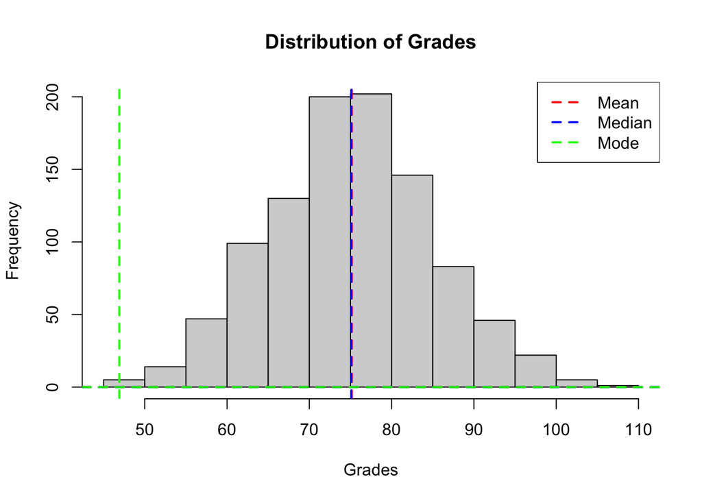

```r
# Create a random example of a normal distribution (you would replace this with actual data)
set.seed(123)  # For reproducibility
grades <- rnorm(1000, mean = 75, sd = 10)

# Create a histogram to visualize the distribution
hist(grades, main = "Distribution of Grades", xlab = "Grades")

# Calculate mean, median, and mode
mean_value <- mean(grades)
median_value <- median(grades)
mode_value <- as.numeric(names(sort(table(grades), decreasing = TRUE)[1]))

# Add lines to the plot to label the mean, median, and mode
abline(v = mean_value, col = "red", lwd = 2, lty = 2, h = 0)
abline(v = median_value, col = "blue", lwd = 2, lty = 2, h = 0)
abline(v = mode_value, col = "green", lwd = 2, lty = 2, h = 0)

# Create a legend
legend("topright", legend = c("Mean", "Median", "Mode"), col = c("red", "blue", "green"), lty = 2, lwd = 2)
```

## e.

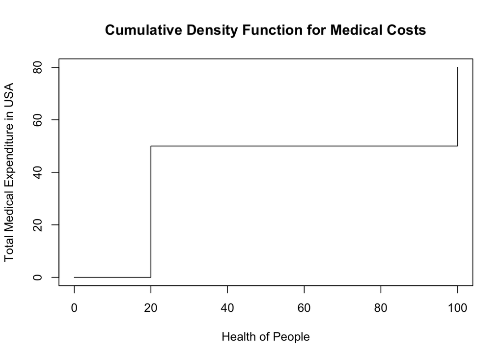

```r
# Create data for CDF
x <- c(0, 20, 100)  # Assuming 0% to 100% of people's health
y <- c(0, 50, 80)   # Corresponding medical cost percentages

# Create the CDF plot
plot(x, y, type = "s", xlab = "Health of People", ylab = "Total Medical Expenditure in USA",
     main = "Cumulative Density Function for Medical Costs")
```